# 算法训练营Day 17

Author

Siru Wu

Published

February 2, 2026

## [654. 最大二叉树](https://leetcode.cn/problems/maximum-binary-tree/description/)

> 给定一个不重复的整数数组 nums 。 最大二叉树 可以用下面的算法从 nums 递归地构建:
> - 创建一个根节点，其值为 nums 中的最大值。
> - 递归地在最大值 左边 的 子数组前缀上 构建左子树。
> - 递归地在最大值 右边 的 子数组后缀上 构建右子树。
> - 返回 nums 构建的 最大二叉树 。

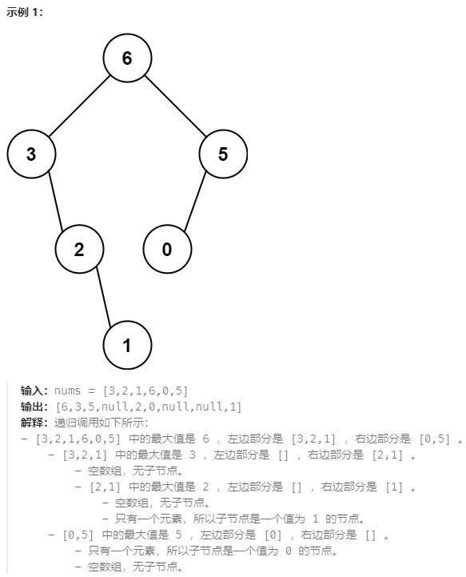

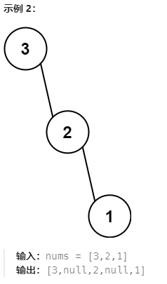

```python
# Definition for a binary tree node.
# class TreeNode:
#     def __init__(self, val=0, left=None, right=None):
#         self.val = val
#         self.left = left
#         self.right = right
class Solution:
    def constructMaximumBinaryTree(self, nums: List[int]) -> Optional[TreeNode]:
        if not nums: # 一定记得先判断是否是空的
            return None
        root_val = max(nums)
        root = TreeNode(root_val)

        seperator_idx = nums.index(root_val)

        left = nums[:seperator_idx]
        right = nums[seperator_idx + 1:]

        root.left = self.constructMaximumBinaryTree(left)
        root.right = self.constructMaximumBinaryTree(right)

        return root
```

这是进入二叉树以来第一道我能直接秒的题目哈哈哈哈哈哈，太开心了。这么多天了写二叉树写的怀疑人生。

## [617. 合并二叉树](https://leetcode.cn/problems/merge-two-binary-trees/description/)

> 给你两棵二叉树： root1 和 root2 。

> 想象一下，当你将其中一棵覆盖到另一棵之上时，两棵树上的一些节点将会重叠（而另一些不会）。你需要将这两棵树合并成一棵新二叉树。合并的规则是：如果两个节点重叠，那么将这两个节点的值相加作为合并后节点的新值；否则，不为 null 的节点将直接作为新二叉树的节点。

> 返回合并后的二叉树。

> 注意: 合并过程必须从两个树的根节点开始。

### 递归法

```python
# Definition for a binary tree node.
# class TreeNode:
#     def __init__(self, val=0, left=None, right=None):
#         self.val = val
#         self.left = left
#         self.right = right
class Solution:
    def mergeTrees(self, root1: Optional[TreeNode], root2: Optional[TreeNode]) -> Optional[TreeNode]:
        if not root1:
            return root2
        if not root2:
            return root1

        root1.val += root2.val
        root1.left = self.mergeTrees(root1.left, root2.left)
        root1.right = self.mergeTrees(root1.right, root2.right)
        return root1
```

### BFS 迭代法

```python
# Definition for a binary tree node.
# class TreeNode:
#     def __init__(self, val=0, left=None, right=None):
#         self.val = val
#         self.left = left
#         self.right = right
class Solution:
    def mergeTrees(self, root1: Optional[TreeNode], root2: Optional[TreeNode]) -> Optional[TreeNode]:
        if not root1:
            return root2
        if not root2:
            return root1

        queue = deque()
        queue.append(root1)
        queue.append(root2)

        while queue:
            node1 = queue.popleft()
            node2 = queue.popleft()
            if node1.left and node2.left:
                queue.append(node1.left)
                queue.append(node2.left)
            if node1.right and node2.right:
                queue.append(node1.right)
                queue.append(node2.right)

            node1.val += node2.val
            if not node1.left and node2.left:
                node1.left = node2.left
            if not node1.right and node2.right:
                node1.right = node2.right
        return root1
```

## [700.二叉搜索树中的搜索](https://leetcode.cn/problems/search-in-a-binary-search-tree/description/)

> 给定二叉搜索树（BST）的根节点 root 和一个整数值 val。

> 你需要在 BST 中找到节点值等于 val 的节点。 返回以该节点为根的子树。 如果节点不存在，则返回 null 。

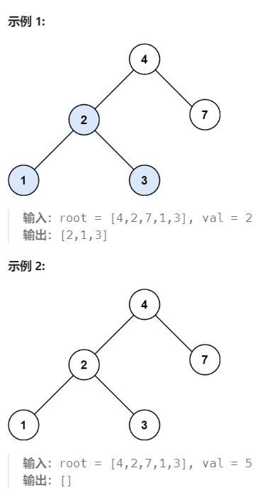

**BST 的定义保证：**

- 左子树所有值 < root.val
- 右子树所有值 > root.val

### 递归法

```python
# Definition for a binary tree node.
# class TreeNode:
#     def __init__(self, val=0, left=None, right=None):
#         self.val = val
#         self.left = left
#         self.right = right
class Solution:
    def searchBST(self, root: Optional[TreeNode], val: int) -> Optional[TreeNode]:
        if not root or root.val == val:
            return root

        if root.val > val: # BST保证如果val小于root.val的话，它一定在左子树上
            return self.searchBST(root.left, val)

        if root.val < val:
            return self.searchBST(root.right, val)
```

### 迭代法

```python
# Definition for a binary tree node.
# class TreeNode:
#     def __init__(self, val=0, left=None, right=None):
#         self.val = val
#         self.left = left
#         self.right = right
class Solution:
    def searchBST(self, root: Optional[TreeNode], val: int) -> Optional[TreeNode]:
        while root:
            if root.val > val:
                root = root.left
            elif root.val < val:
                root = root.right
            else:
                return root
```

## [98.验证二叉搜索树](https://leetcode.cn/problems/validate-binary-search-tree/description/)

> 给你一个二叉树的根节点 root ，判断其是否是一个有效的二叉搜索树。

> 有效 二叉搜索树定义如下：

> 节点的左子树只包含 严格小于 当前节点的数。

> 节点的右子树只包含 严格大于 当前节点的数。

> 所有左子树和右子树自身必须也是二叉搜索树。

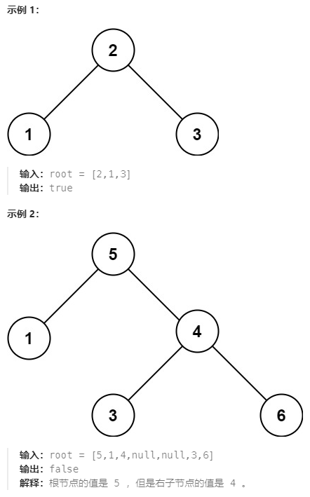

### 递归法（版本一）利用中序递增性质，转换成数组

```python
# Definition for a binary tree node.
# class TreeNode:
#     def __init__(self, val=0, left=None, right=None):
#         self.val = val
#         self.left = left
#         self.right = right
class Solution:
    def __init__(self):
        self.vec = []

    def traversal(self, root):
        if not root:
            return

        # 中序遍历
        self.traversal(root.left)
        self.vec.append(root.val) # 这里append的是root.val, 而不是root
        self.traversal(root.right)

    def isValidBST(self, root: Optional[TreeNode]) -> bool:
        self.vec = []
        self.traversal(root)
        for i in range(1, len(self.vec)): # 这里要写self.vec而不是vec
            # 检查数组是不是 单调递增
            if self.vec[i] <= self.vec[i - 1]:
                return False
        return True
```

### 递归法（版本二）设定极小值，进行比较

```python
class Solution:
    def __init__(self):
        self.maxVal = float('-inf')

    def isValidBST(self, root: Optional[TreeNode]) -> bool:
        if not root:
            return True

        # 这一段是按照 left -> mid -> right写的，就规定了跑的是中序遍历
        left = self.isValidBST(root.left)

        if self.maxVal < root.val:
            self.maxVal = root.val
        else:
            return False

        right = self.isValidBST(root.right)

        # left和right都返回的是bool值
        return left and right
```

```python
class Solution:
    def __init__(self):
        self.pre = None

    def isValidBST(self, root: Optional[TreeNode]) -> bool:
        if not root:
            return True

        left  = self.isValidBST(root.left)

        if self.pre is not None and self.pre.val >= root.val:
            return False
            self.pre = root

        right = self.isValidBST(root.right)
        return left and right
```